# Risk Factor Analysis

## Outcome Variable

**Outcome Variable:** ever_stunted

## Predictor Variables

**Intervention Variable:** fhtcm

**Adjustment Set:**

unadjusted

## Stratifying Variables

The analysis was stratified on these variable(s):

- agecat
- studyid
- country

## Data Summary

| agecat | studyid | country | fhtcm | ever_stunted | n_cell | n |
| --- | --- | --- | --- | --- | --- | --- |
| 0-6 months | ki1000304b-SAS-CompFeed | INDIA | [160-170) | 0 | 368 | 905 |
| 0-6 months | ki1000304b-SAS-CompFeed | INDIA | [160-170) | 1 | 149 | 905 |
| 0-6 months | ki1000304b-SAS-CompFeed | INDIA | <160 | 0 | 81 | 905 |
| 0-6 months | ki1000304b-SAS-CompFeed | INDIA | <160 | 1 | 54 | 905 |
| 0-6 months | ki1000304b-SAS-CompFeed | INDIA | >=170 | 0 | 194 | 905 |
| 0-6 months | ki1000304b-SAS-CompFeed | INDIA | >=170 | 1 | 59 | 905 |
| 0-6 months | ki1000304b-SAS-FoodSuppl | INDIA | [160-170) | 0 | 148 | 397 |
| 0-6 months | ki1000304b-SAS-FoodSuppl | INDIA | [160-170) | 1 | 91 | 397 |
| 0-6 months | ki1000304b-SAS-FoodSuppl | INDIA | <160 | 0 | 55 | 397 |
| 0-6 months | ki1000304b-SAS-FoodSuppl | INDIA | <160 | 1 | 48 | 397 |
| 0-6 months | ki1000304b-SAS-FoodSuppl | INDIA | >=170 | 0 | 42 | 397 |
| 0-6 months | ki1000304b-SAS-FoodSuppl | INDIA | >=170 | 1 | 13 | 397 |
| 0-6 months | ki1101329-Keneba | GAMBIA | [160-170) | 0 | 851 | 1723 |
| 0-6 months | ki1101329-Keneba | GAMBIA | [160-170) | 1 | 86 | 1723 |
| 0-6 months | ki1101329-Keneba | GAMBIA | <160 | 0 | 32 | 1723 |
| 0-6 months | ki1101329-Keneba | GAMBIA | <160 | 1 | 6 | 1723 |
| 0-6 months | ki1101329-Keneba | GAMBIA | >=170 | 0 | 697 | 1723 |
| 0-6 months | ki1101329-Keneba | GAMBIA | >=170 | 1 | 51 | 1723 |
| 0-6 months | ki1119695-PROBIT | BELARUS | [160-170) | 0 | 1384 | 12537 |
| 0-6 months | ki1119695-PROBIT | BELARUS | [160-170) | 1 | 3 | 12537 |
| 0-6 months | ki1119695-PROBIT | BELARUS | <160 | 0 | 54 | 12537 |
| 0-6 months | ki1119695-PROBIT | BELARUS | <160 | 1 | 0 | 12537 |
| 0-6 months | ki1119695-PROBIT | BELARUS | >=170 | 0 | 11070 | 12537 |
| 0-6 months | ki1119695-PROBIT | BELARUS | >=170 | 1 | 26 | 12537 |
| 0-6 months | ki1135781-COHORTS | GUATEMALA | [160-170) | 0 | 132 | 337 |
| 0-6 months | ki1135781-COHORTS | GUATEMALA | [160-170) | 1 | 29 | 337 |
| 0-6 months | ki1135781-COHORTS | GUATEMALA | <160 | 0 | 115 | 337 |
| 0-6 months | ki1135781-COHORTS | GUATEMALA | <160 | 1 | 35 | 337 |
| 0-6 months | ki1135781-COHORTS | GUATEMALA | >=170 | 0 | 22 | 337 |
| 0-6 months | ki1135781-COHORTS | GUATEMALA | >=170 | 1 | 4 | 337 |

[output cut: 60 more lines]

The following strata were considered:

- agecat: 0-24 months, studyid: ki1000304b-SAS-CompFeed, country: INDIA
- agecat: 0-24 months, studyid: ki1000304b-SAS-FoodSuppl, country: INDIA
- agecat: 0-24 months, studyid: ki1101329-Keneba, country: GAMBIA
- agecat: 0-24 months, studyid: ki1119695-PROBIT, country: BELARUS
- agecat: 0-24 months, studyid: ki1135781-COHORTS, country: GUATEMALA
- agecat: 0-6 months, studyid: ki1000304b-SAS-CompFeed, country: INDIA
- agecat: 0-6 months, studyid: ki1000304b-SAS-FoodSuppl, country: INDIA
- agecat: 0-6 months, studyid: ki1101329-Keneba, country: GAMBIA
- agecat: 0-6 months, studyid: ki1119695-PROBIT, country: BELARUS
- agecat: 0-6 months, studyid: ki1135781-COHORTS, country: GUATEMALA
- agecat: 6-24 months, studyid: ki1000304b-SAS-CompFeed, country: INDIA
- agecat: 6-24 months, studyid: ki1000304b-SAS-FoodSuppl, country: INDIA
- agecat: 6-24 months, studyid: ki1101329-Keneba, country: GAMBIA
- agecat: 6-24 months, studyid: ki1119695-PROBIT, country: BELARUS
- agecat: 6-24 months, studyid: ki1135781-COHORTS, country: GUATEMALA

### Dropped Strata

Some strata were dropped due to rare outcomes:

- agecat: 0-6 months, studyid: ki1119695-PROBIT, country: BELARUS
- agecat: 0-6 months, studyid: ki1135781-COHORTS, country: GUATEMALA

## Methods Detail

We’re interested in the causal parameters $E[Y_a]$ for all values of $a \in \mathcal{A}$. These parameters represent the mean outcome if, possibly contrary to fact, we intervened to set all units to have $A=a$. Under the randomization and positivity assumptions, these are identified by the statistical parameters $\psi_a=E_W[E_{Y|A,W}(Y|A=a,W)]$. In addition, we’re interested in the mean of $Y$, $E[Y]$ under no intervention (the observed mean). We will estimate these parameters by using SuperLearner to fit the relevant likelihood factors – $E_{Y|A,W}(Y|A=a,W)$ and $p(A=a|W)$, and then updating our likelihood fit using a joint TMLE.

For unadjusted analyses ($W=\{\}$), initial likelihoods were estimated using Lrnr_glm to estimate the simple $E(Y|A)$ and Lrnr_mean to estimate $p(A)$. For adjusted analyses, a small library containing Lrnr_glmnet, Lrnr_xgboost, and Lrnr_mean was used.

Having estimated these parameters, we will then use the delta method to estimate relative risks and attributable risks relative to a prespecified baseline level of $A$.

# Results Detail

## Results Plots

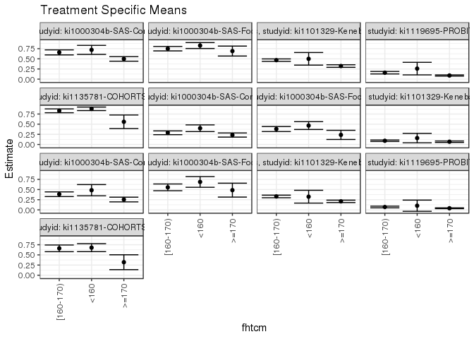

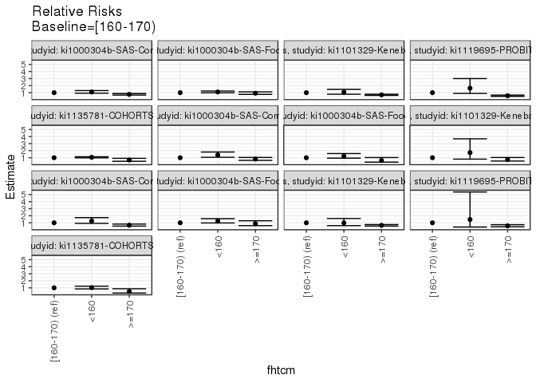

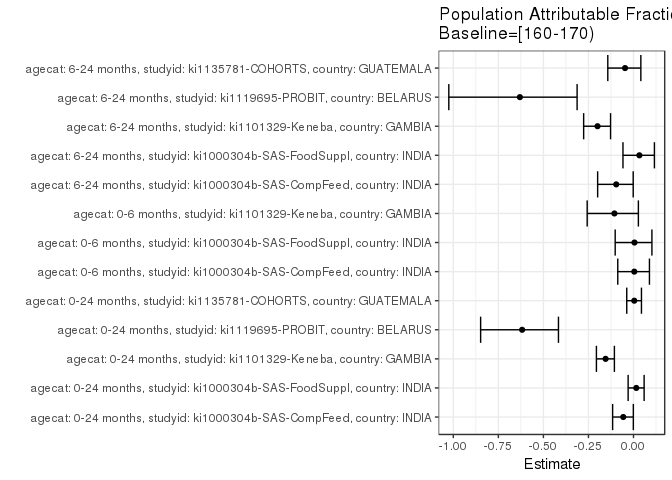

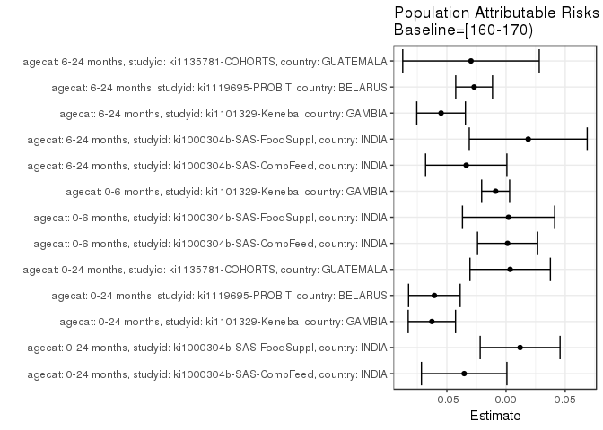

## Results Table

### Parameter: TSM

| agecat | studyid | country | intervention_level | baseline_level | estimate | ci_lower | ci_upper |
| --- | --- | --- | --- | --- | --- | --- | --- |
| 0-24 months | ki1000304b-SAS-CompFeed | INDIA | [160-170) | NA | 0.6583012 | 0.5967375 | 0.7198649 |
| 0-24 months | ki1000304b-SAS-CompFeed | INDIA | <160 | NA | 0.7205882 | 0.6094779 | 0.8316985 |
| 0-24 months | ki1000304b-SAS-CompFeed | INDIA | >=170 | NA | 0.4980237 | 0.4421210 | 0.5539265 |
| 0-24 months | ki1000304b-SAS-FoodSuppl | INDIA | [160-170) | NA | 0.7500000 | 0.6951486 | 0.8048514 |
| 0-24 months | ki1000304b-SAS-FoodSuppl | INDIA | <160 | NA | 0.8269231 | 0.7541236 | 0.8997226 |
| 0-24 months | ki1000304b-SAS-FoodSuppl | INDIA | >=170 | NA | 0.6909091 | 0.5686263 | 0.8131918 |
| 0-24 months | ki1101329-Keneba | GAMBIA | [160-170) | NA | 0.4675573 | 0.4373415 | 0.4977730 |
| 0-24 months | ki1101329-Keneba | GAMBIA | <160 | NA | 0.5000000 | 0.3450111 | 0.6549889 |
| 0-24 months | ki1101329-Keneba | GAMBIA | >=170 | NA | 0.3222354 | 0.2906426 | 0.3538283 |
| 0-24 months | ki1119695-PROBIT | BELARUS | [160-170) | NA | 0.1586157 | 0.1279943 | 0.1892372 |
| 0-24 months | ki1119695-PROBIT | BELARUS | <160 | NA | 0.2592593 | 0.1041328 | 0.4143857 |
| 0-24 months | ki1119695-PROBIT | BELARUS | >=170 | NA | 0.0896720 | 0.0746330 | 0.1047109 |
| 0-24 months | ki1135781-COHORTS | GUATEMALA | [160-170) | NA | 0.8291667 | 0.7815029 | 0.8768304 |
| 0-24 months | ki1135781-COHORTS | GUATEMALA | <160 | NA | 0.8783784 | 0.8353400 | 0.9214168 |
| 0-24 months | ki1135781-COHORTS | GUATEMALA | >=170 | NA | 0.5588235 | 0.3917566 | 0.7258904 |
| 0-6 months | ki1000304b-SAS-CompFeed | INDIA | [160-170) | NA | 0.2882012 | 0.2416965 | 0.3347059 |
| 0-6 months | ki1000304b-SAS-CompFeed | INDIA | <160 | NA | 0.4000000 | 0.3176566 | 0.4823434 |
| 0-6 months | ki1000304b-SAS-CompFeed | INDIA | >=170 | NA | 0.2332016 | 0.1817604 | 0.2846427 |
| 0-6 months | ki1000304b-SAS-FoodSuppl | INDIA | [160-170) | NA | 0.3807531 | 0.3191149 | 0.4423914 |
| 0-6 months | ki1000304b-SAS-FoodSuppl | INDIA | <160 | NA | 0.4660194 | 0.3695606 | 0.5624782 |
| 0-6 months | ki1000304b-SAS-FoodSuppl | INDIA | >=170 | NA | 0.2363636 | 0.1239425 | 0.3487848 |
| 0-6 months | ki1101329-Keneba | GAMBIA | [160-170) | NA | 0.0917823 | 0.0732905 | 0.1102741 |
| 0-6 months | ki1101329-Keneba | GAMBIA | <160 | NA | 0.1578947 | 0.0419237 | 0.2738657 |
| 0-6 months | ki1101329-Keneba | GAMBIA | >=170 | NA | 0.0681818 | 0.0501133 | 0.0862504 |
| 6-24 months | ki1000304b-SAS-CompFeed | INDIA | [160-170) | NA | 0.3846154 | 0.3274289 | 0.4418019 |
| 6-24 months | ki1000304b-SAS-CompFeed | INDIA | <160 | NA | 0.4838710 | 0.3454974 | 0.6222445 |
| 6-24 months | ki1000304b-SAS-CompFeed | INDIA | >=170 | NA | 0.2538860 | 0.1961373 | 0.3116347 |
| 6-24 months | ki1000304b-SAS-FoodSuppl | INDIA | [160-170) | NA | 0.5539568 | 0.4711328 | 0.6367809 |
| 6-24 months | ki1000304b-SAS-FoodSuppl | INDIA | <160 | NA | 0.6875000 | 0.5560750 | 0.8189250 |
| 6-24 months | ki1000304b-SAS-FoodSuppl | INDIA | >=170 | NA | 0.4848485 | 0.3139450 | 0.6557520 |
| 6-24 months | ki1101329-Keneba | GAMBIA | [160-170) | NA | 0.3297998 | 0.2981656 | 0.3614339 |
| 6-24 months | ki1101329-Keneba | GAMBIA | <160 | NA | 0.3235294 | 0.1662310 | 0.4808279 |
| 6-24 months | ki1101329-Keneba | GAMBIA | >=170 | NA | 0.2090164 | 0.1795518 | 0.2384810 |
| 6-24 months | ki1119695-PROBIT | BELARUS | [160-170) | NA | 0.0697329 | 0.0489598 | 0.0905061 |
| 6-24 months | ki1119695-PROBIT | BELARUS | <160 | NA | 0.1020408 | -0.0356623 | 0.2397439 |
| 6-24 months | ki1119695-PROBIT | BELARUS | >=170 | NA | 0.0391817 | 0.0295917 | 0.0487716 |
| 6-24 months | ki1135781-COHORTS | GUATEMALA | [160-170) | NA | 0.6614173 | 0.5789415 | 0.7438932 |
| 6-24 months | ki1135781-COHORTS | GUATEMALA | <160 | NA | 0.6781609 | 0.5797859 | 0.7765359 |
| 6-24 months | ki1135781-COHORTS | GUATEMALA | >=170 | NA | 0.3200000 | 0.1367610 | 0.5032390 |

### Parameter: E(Y)

| agecat | studyid | country | intervention_level | baseline_level | estimate | ci_lower | ci_upper |
| --- | --- | --- | --- | --- | --- | --- | --- |
| 0-24 months | ki1000304b-SAS-CompFeed | INDIA | NA | NA | 0.6229327 | 0.5785357 | 0.6673298 |
| 0-24 months | ki1000304b-SAS-FoodSuppl | INDIA | NA | NA | 0.7619048 | 0.7200609 | 0.8037487 |
| 0-24 months | ki1101329-Keneba | GAMBIA | NA | NA | 0.4048730 | 0.3829622 | 0.4267838 |
| 0-24 months | ki1119695-PROBIT | BELARUS | NA | NA | 0.0980298 | 0.0820346 | 0.1140250 |
| 0-24 months | ki1135781-COHORTS | GUATEMALA | NA | NA | 0.8326613 | 0.7997778 | 0.8655448 |
| 0-6 months | ki1000304b-SAS-CompFeed | INDIA | NA | NA | 0.2895028 | 0.2525193 | 0.3264862 |
| 0-6 months | ki1000304b-SAS-FoodSuppl | INDIA | NA | NA | 0.3828715 | 0.3349959 | 0.4307472 |
| 0-6 months | ki1101329-Keneba | GAMBIA | NA | NA | 0.0829948 | 0.0699648 | 0.0960247 |
| 6-24 months | ki1000304b-SAS-CompFeed | INDIA | NA | NA | 0.3509700 | 0.3057207 | 0.3962194 |
| 6-24 months | ki1000304b-SAS-FoodSuppl | INDIA | NA | NA | 0.5727273 | 0.5072105 | 0.6382441 |
| 6-24 months | ki1101329-Keneba | GAMBIA | NA | NA | 0.2749226 | 0.2531408 | 0.2967044 |
| 6-24 months | ki1119695-PROBIT | BELARUS | NA | NA | 0.0427669 | 0.0325915 | 0.0529422 |
| 6-24 months | ki1135781-COHORTS | GUATEMALA | NA | NA | 0.6317992 | 0.5705230 | 0.6930753 |

### Parameter: RR

| agecat | studyid | country | intervention_level | baseline_level | estimate | ci_lower | ci_upper |
| --- | --- | --- | --- | --- | --- | --- | --- |
| 0-24 months | ki1000304b-SAS-CompFeed | INDIA | [160-170) | [160-170) | 1.0000000 | 1.0000000 | 1.0000000 |
| 0-24 months | ki1000304b-SAS-CompFeed | INDIA | <160 | [160-170) | 1.0946179 | 0.9233864 | 1.2976023 |
| 0-24 months | ki1000304b-SAS-CompFeed | INDIA | >=170 | [160-170) | 0.7565287 | 0.6568789 | 0.8712956 |
| 0-24 months | ki1000304b-SAS-FoodSuppl | INDIA | [160-170) | [160-170) | 1.0000000 | 1.0000000 | 1.0000000 |
| 0-24 months | ki1000304b-SAS-FoodSuppl | INDIA | <160 | [160-170) | 1.1025641 | 0.9833272 | 1.2362595 |
| 0-24 months | ki1000304b-SAS-FoodSuppl | INDIA | >=170 | [160-170) | 0.9212121 | 0.7606603 | 1.1156515 |
| 0-24 months | ki1101329-Keneba | GAMBIA | [160-170) | [160-170) | 1.0000000 | 1.0000000 | 1.0000000 |
| 0-24 months | ki1101329-Keneba | GAMBIA | <160 | [160-170) | 1.0693878 | 0.7791463 | 1.4677477 |
| 0-24 months | ki1101329-Keneba | GAMBIA | >=170 | [160-170) | 0.6891893 | 0.6128318 | 0.7750607 |
| 0-24 months | ki1119695-PROBIT | BELARUS | [160-170) | [160-170) | 1.0000000 | 1.0000000 | 1.0000000 |
| 0-24 months | ki1119695-PROBIT | BELARUS | <160 | [160-170) | 1.6345118 | 0.8908692 | 2.9989013 |
| 0-24 months | ki1119695-PROBIT | BELARUS | >=170 | [160-170) | 0.5653409 | 0.4818673 | 0.6632746 |
| 0-24 months | ki1135781-COHORTS | GUATEMALA | [160-170) | [160-170) | 1.0000000 | 1.0000000 | 1.0000000 |
| 0-24 months | ki1135781-COHORTS | GUATEMALA | <160 | [160-170) | 1.0593508 | 0.9822826 | 1.1424656 |
| 0-24 months | ki1135781-COHORTS | GUATEMALA | >=170 | [160-170) | 0.6739580 | 0.4970694 | 0.9137947 |
| 0-6 months | ki1000304b-SAS-CompFeed | INDIA | [160-170) | [160-170) | 1.0000000 | 1.0000000 | 1.0000000 |
| 0-6 months | ki1000304b-SAS-CompFeed | INDIA | <160 | [160-170) | 1.3879195 | 1.0648554 | 1.8089973 |
| 0-6 months | ki1000304b-SAS-CompFeed | INDIA | >=170 | [160-170) | 0.8091625 | 0.6301467 | 1.0390343 |
| 0-6 months | ki1000304b-SAS-FoodSuppl | INDIA | [160-170) | [160-170) | 1.0000000 | 1.0000000 | 1.0000000 |
| 0-6 months | ki1000304b-SAS-FoodSuppl | INDIA | <160 | [160-170) | 1.2239411 | 0.9411089 | 1.5917731 |
| 0-6 months | ki1000304b-SAS-FoodSuppl | INDIA | >=170 | [160-170) | 0.6207792 | 0.3756105 | 1.0259747 |
| 0-6 months | ki1101329-Keneba | GAMBIA | [160-170) | [160-170) | 1.0000000 | 1.0000000 | 1.0000000 |
| 0-6 months | ki1101329-Keneba | GAMBIA | <160 | [160-170) | 1.7203182 | 0.8032369 | 3.6844606 |
| 0-6 months | ki1101329-Keneba | GAMBIA | >=170 | [160-170) | 0.7428647 | 0.5325186 | 1.0362979 |
| 6-24 months | ki1000304b-SAS-CompFeed | INDIA | [160-170) | [160-170) | 1.0000000 | 1.0000000 | 1.0000000 |
| 6-24 months | ki1000304b-SAS-CompFeed | INDIA | <160 | [160-170) | 1.2580645 | 0.9134783 | 1.7326370 |
| 6-24 months | ki1000304b-SAS-CompFeed | INDIA | >=170 | [160-170) | 0.6601036 | 0.5318279 | 0.8193192 |
| 6-24 months | ki1000304b-SAS-FoodSuppl | INDIA | [160-170) | [160-170) | 1.0000000 | 1.0000000 | 1.0000000 |
| 6-24 months | ki1000304b-SAS-FoodSuppl | INDIA | <160 | [160-170) | 1.2410714 | 0.9736399 | 1.5819588 |
| 6-24 months | ki1000304b-SAS-FoodSuppl | INDIA | >=170 | [160-170) | 0.8752460 | 0.5968215 | 1.2835589 |
| 6-24 months | ki1101329-Keneba | GAMBIA | [160-170) | [160-170) | 1.0000000 | 1.0000000 | 1.0000000 |
| 6-24 months | ki1101329-Keneba | GAMBIA | <160 | [160-170) | 0.9809874 | 0.5976426 | 1.6102203 |
| 6-24 months | ki1101329-Keneba | GAMBIA | >=170 | [160-170) | 0.6337676 | 0.5344166 | 0.7515884 |
| 6-24 months | ki1119695-PROBIT | BELARUS | [160-170) | [160-170) | 1.0000000 | 1.0000000 | 1.0000000 |
| 6-24 months | ki1119695-PROBIT | BELARUS | <160 | [160-170) | 1.4633087 | 0.3991227 | 5.3649473 |
| 6-24 months | ki1119695-PROBIT | BELARUS | >=170 | [160-170) | 0.5618817 | 0.4328528 | 0.7293727 |
| 6-24 months | ki1135781-COHORTS | GUATEMALA | [160-170) | [160-170) | 1.0000000 | 1.0000000 | 1.0000000 |
| 6-24 months | ki1135781-COHORTS | GUATEMALA | <160 | [160-170) | 1.0253147 | 0.8468004 | 1.2414617 |
| 6-24 months | ki1135781-COHORTS | GUATEMALA | >=170 | [160-170) | 0.4838095 | 0.2692525 | 0.8693389 |

### Parameter: PAR

| agecat | studyid | country | intervention_level | baseline_level | estimate | ci_lower | ci_upper |
| --- | --- | --- | --- | --- | --- | --- | --- |
| 0-24 months | ki1000304b-SAS-CompFeed | INDIA | [160-170) | NA | -0.0353684 | -0.0714791 | 0.0007423 |
| 0-24 months | ki1000304b-SAS-FoodSuppl | INDIA | [160-170) | NA | 0.0119048 | -0.0218610 | 0.0456705 |
| 0-24 months | ki1101329-Keneba | GAMBIA | [160-170) | NA | -0.0626843 | -0.0827103 | -0.0426582 |
| 0-24 months | ki1119695-PROBIT | BELARUS | [160-170) | NA | -0.0605859 | -0.0823900 | -0.0387817 |
| 0-24 months | ki1135781-COHORTS | GUATEMALA | [160-170) | NA | 0.0034946 | -0.0304849 | 0.0374742 |
| 0-6 months | ki1000304b-SAS-CompFeed | INDIA | [160-170) | NA | 0.0013016 | -0.0241065 | 0.0267097 |
| 0-6 months | ki1000304b-SAS-FoodSuppl | INDIA | [160-170) | NA | 0.0021184 | -0.0368292 | 0.0410660 |
| 0-6 months | ki1101329-Keneba | GAMBIA | [160-170) | NA | -0.0087875 | -0.0206117 | 0.0030367 |
| 6-24 months | ki1000304b-SAS-CompFeed | INDIA | [160-170) | NA | -0.0336454 | -0.0680151 | 0.0007244 |
| 6-24 months | ki1000304b-SAS-FoodSuppl | INDIA | [160-170) | NA | 0.0187704 | -0.0310688 | 0.0686097 |
| 6-24 months | ki1101329-Keneba | GAMBIA | [160-170) | NA | -0.0548772 | -0.0754445 | -0.0343098 |
| 6-24 months | ki1119695-PROBIT | BELARUS | [160-170) | NA | -0.0269660 | -0.0425074 | -0.0114247 |
| 6-24 months | ki1135781-COHORTS | GUATEMALA | [160-170) | NA | -0.0296182 | -0.0873057 | 0.0280693 |

### Parameter: PAF

| agecat | studyid | country | intervention_level | baseline_level | estimate | ci_lower | ci_upper |
| --- | --- | --- | --- | --- | --- | --- | --- |
| 0-24 months | ki1000304b-SAS-CompFeed | INDIA | [160-170) | NA | -0.0567773 | -0.1158259 | -0.0008534 |
| 0-24 months | ki1000304b-SAS-FoodSuppl | INDIA | [160-170) | NA | 0.0156250 | -0.0297514 | 0.0590019 |
| 0-24 months | ki1101329-Keneba | GAMBIA | [160-170) | NA | -0.1548245 | -0.2057832 | -0.1060194 |
| 0-24 months | ki1119695-PROBIT | BELARUS | [160-170) | NA | -0.6180352 | -0.8483509 | -0.4164182 |
| 0-24 months | ki1135781-COHORTS | GUATEMALA | [160-170) | NA | 0.0041969 | -0.0374623 | 0.0441833 |
| 0-6 months | ki1000304b-SAS-CompFeed | INDIA | [160-170) | NA | 0.0044960 | -0.0873053 | 0.0885465 |
| 0-6 months | ki1000304b-SAS-FoodSuppl | INDIA | [160-170) | NA | 0.0055329 | -0.1015773 | 0.1022285 |
| 0-6 months | ki1101329-Keneba | GAMBIA | [160-170) | NA | -0.1058802 | -0.2570496 | 0.0271099 |
| 6-24 months | ki1000304b-SAS-CompFeed | INDIA | [160-170) | NA | -0.0958639 | -0.1989712 | -0.0016235 |
| 6-24 months | ki1000304b-SAS-FoodSuppl | INDIA | [160-170) | NA | 0.0327738 | -0.0584225 | 0.1161124 |
| 6-24 months | ki1101329-Keneba | GAMBIA | [160-170) | NA | -0.1996095 | -0.2766422 | -0.1272250 |
| 6-24 months | ki1119695-PROBIT | BELARUS | [160-170) | NA | -0.6305357 | -1.0249269 | -0.3129593 |
| 6-24 months | ki1135781-COHORTS | GUATEMALA | [160-170) | NA | -0.0468791 | -0.1426057 | 0.0408276 |